# The female rivalry hypothesis - Main Experiments

Scott Claessens

2020-12-01

# 0. Setup

Load packages.

```r
library(tidyverse)
library(effsize)
library(gtable)
library(grid)
library(ggplotify)
```

Load data.

```r
d <- read.csv('data/v6/cleanData/ovulationMainExperiments.csv', header = TRUE)

d
```

| Experiment | Run | Decrement | Strategy | PI | RS |
| --- | --- | --- | --- | --- | --- |
| 1 | 1 | TRUE | Concealers | 7325.84 | 7.26 |
| 1 | 1 | TRUE | Revealers | 6393.14 | 6.96 |
| 1 | 2 | TRUE | Concealers | 5593.68 | 6.42 |
| 1 | 2 | TRUE | Revealers | 5240.68 | 6.26 |
| 1 | 3 | TRUE | Concealers | 6352.40 | 6.90 |
| 1 | 3 | TRUE | Revealers | 7542.60 | 7.38 |
| 1 | 4 | TRUE | Concealers | 6415.66 | 6.72 |
| 1 | 4 | TRUE | Revealers | 4579.62 | 6.04 |
| 1 | 5 | TRUE | Concealers | 5368.76 | 6.34 |
| 1 | 5 | TRUE | Revealers | 5908.04 | 6.64 |

[output cut: 9990 more lines]

Our outcome variables are paternal investment (PI) and lifetime reproductive success (RS). There are 120,000 rows in this dataset (3 experiments x 10000 model runs x 2 decrement parameters x 2 female strategies).

# 1. Experiment 1 (No Aggression)

## 1.1. Reproductive Success

Focusing on Experiment 1 first, visualise outcome and check assumptions of normality.

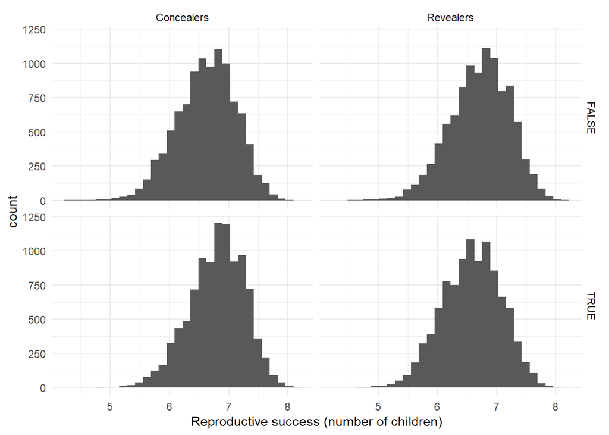

```r
d %>%
  filter(Experiment == 1) %>%

  ggplot(aes(x = RS)) +
  geom_histogram(bins=30) +
  facet_grid(Decrement ~ Strategy) +
  xlab('Reproductive success (number of children)') +
  theme_minimal()
```

These look normally-distributed. Next, run paired t-tests to look for differences between strategies.

```r
RS.dFalse.Revealers  <- d %>% filter(Experiment==1, Decrement=='FALSE', Strategy=='Revealers') %>% pull(RS)
RS.dFalse.Concealers <- d %>% filter(Experiment==1, Decrement=='FALSE', Strategy=='Concealers') %>% pull(RS)
RS.dTrue.Revealers   <- d %>% filter(Experiment==1, Decrement=='TRUE', Strategy=='Revealers') %>% pull(RS)
RS.dTrue.Concealers  <- d %>% filter(Experiment==1, Decrement=='TRUE', Strategy=='Concealers') %>% pull(RS)

t.test(RS.dFalse.Revealers, RS.dFalse.Concealers, paired = TRUE)
```

```
##
##  Paired t-test
##
## data:  RS.dFalse.Revealers and RS.dFalse.Concealers
## t = 14.576, df = 9999, p-value < 2.2e-16
## alternative hypothesis: true difference in means is not equal to 0
## 95 percent confidence interval:
##  0.07973503 0.10451297
## sample estimates:
## mean of the differences
##                0.092124
```

```r
cohen.d(RS.dFalse.Revealers, RS.dFalse.Concealers, paired = TRUE)
```

```
##
## Cohen's d
##
## d estimate: 0.1867754 (negligible)
## 95 percent confidence interval:
##     lower     upper
## 0.1614410 0.2121098
```

When Decrement == FALSE, there is a significant difference between the reproductive success of Revealers (Mean = 6.71 children) and Concealers (Mean = 6.62 children), with an effect size of 0.19.

```r
t.test(RS.dTrue.Revealers, RS.dTrue.Concealers, paired = TRUE)
```

```
##
##  Paired t-test
##
## data:  RS.dTrue.Revealers and RS.dTrue.Concealers
## t = -37.285, df = 9999, p-value < 2.2e-16
## alternative hypothesis: true difference in means is not equal to 0
## 95 percent confidence interval:
##  -0.2343217 -0.2109143
## sample estimates:
## mean of the differences
##               -0.222618
```

```r
cohen.d(RS.dTrue.Revealers, RS.dTrue.Concealers, paired = TRUE)
```

```
##
## Cohen's d
##
## d estimate: -0.462529 (small)
## 95 percent confidence interval:
##      lower      upper
## -0.4881115 -0.4369464
```

When Decrement == TRUE, there is a significant difference between the reproductive success of Revealers (Mean = 6.58 children) and Concealers (Mean = 6.8 children), with an effect size of -0.46.

## 1.2. Paternal Investment

Now we check the PI outcome, in Experiment 1.

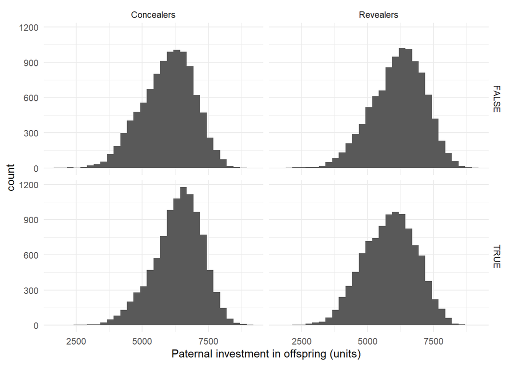

```r
d %>%
  filter(Experiment == 1) %>%

  ggplot(aes(x = PI)) +
  geom_histogram(bins=30) +
  facet_grid(Decrement ~ Strategy) +
  xlab('Paternal investment in offspring (units)') +
  theme_minimal()
```

These also look normally-distributed. Run paired t-tests to look for differences between strategies.

```r
PI.dFalse.Revealers  <- d %>% filter(Experiment==1, Decrement=='FALSE', Strategy=='Revealers') %>% pull(PI)
PI.dFalse.Concealers <- d %>% filter(Experiment==1, Decrement=='FALSE', Strategy=='Concealers') %>% pull(PI)
PI.dTrue.Revealers   <- d %>% filter(Experiment==1, Decrement=='TRUE', Strategy=='Revealers') %>% pull(PI)
PI.dTrue.Concealers  <- d %>% filter(Experiment==1, Decrement=='TRUE', Strategy=='Concealers') %>% pull(PI)

t.test(PI.dFalse.Revealers, PI.dFalse.Concealers, paired = TRUE)
```

```
##
##  Paired t-test
##
## data:  PI.dFalse.Revealers and PI.dFalse.Concealers
## t = 13.448, df = 9999, p-value < 2.2e-16
## alternative hypothesis: true difference in means is not equal to 0
## 95 percent confidence interval:
##  165.5060 221.9865
## sample estimates:
## mean of the differences
##                193.7463
```

```r
cohen.d(PI.dFalse.Revealers, PI.dFalse.Concealers, paired = TRUE)
```

```
##
## Cohen's d
##
## d estimate: 0.1958143 (negligible)
## 95 percent confidence interval:
##     lower     upper
## 0.1670021 0.2246265
```

When Decrement == FALSE, there is a significant difference between the paternal investment of Revealers (Mean = 6156 units) and Concealers (Mean = 5963 units), with an effect size of 0.2.

```r
t.test(PI.dTrue.Revealers, PI.dTrue.Concealers, paired = TRUE)
```

```
##
##  Paired t-test
##
## data:  PI.dTrue.Revealers and PI.dTrue.Concealers
## t = -37.832, df = 9999, p-value < 2.2e-16
## alternative hypothesis: true difference in means is not equal to 0
## 95 percent confidence interval:
##  -539.6522 -486.4843
## sample estimates:
## mean of the differences
##               -513.0683
```

```r
cohen.d(PI.dTrue.Revealers, PI.dTrue.Concealers, paired = TRUE)
```

```
##
## Cohen's d
##
## d estimate: -0.5340358 (medium)
## 95 percent confidence interval:
##      lower      upper
## -0.5636115 -0.5044602
```

When Decrement == TRUE, there is a significant difference between the paternal investment of Revealers (Mean = 5836 units) and Concealers (Mean = 6349 units), with an effect size of -0.53.

# 2. Experiment 2 (Aggression Towards Higher Mate Value Females)

## 2.1. Reproductive Success

Now we turn to Experiment 2. For reproductive success, visualise outcome and check assumptions of normality.

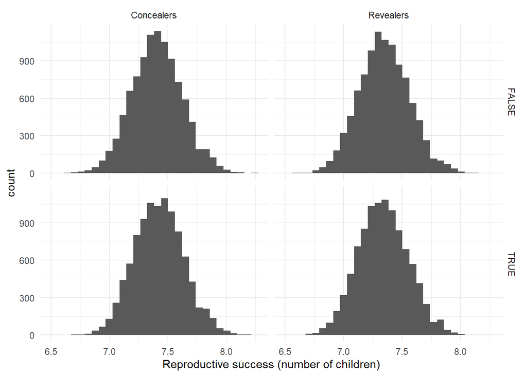

```r
d %>%
  filter(Experiment == 2) %>%

  ggplot(aes(x = RS)) +
  geom_histogram(bins=30) +
  facet_grid(Decrement ~ Strategy) +
  xlab('Reproductive success (number of children)') +
  theme_minimal()
```

As before, these are normally-distributed. Next, run paired t-tests to look for differences between strategies.

```r
RS.dFalse.Revealers  <- d %>% filter(Experiment==2, Decrement=='FALSE', Strategy=='Revealers') %>% pull(RS)
RS.dFalse.Concealers <- d %>% filter(Experiment==2, Decrement=='FALSE', Strategy=='Concealers') %>% pull(RS)
RS.dTrue.Revealers   <- d %>% filter(Experiment==2, Decrement=='TRUE', Strategy=='Revealers') %>% pull(RS)
RS.dTrue.Concealers  <- d %>% filter(Experiment==2, Decrement=='TRUE', Strategy=='Concealers') %>% pull(RS)

t.test(RS.dFalse.Revealers, RS.dFalse.Concealers, paired = TRUE)
```

```
##
##  Paired t-test
##
## data:  RS.dFalse.Revealers and RS.dFalse.Concealers
## t = -19.521, df = 9999, p-value < 2.2e-16
## alternative hypothesis: true difference in means is not equal to 0
## 95 percent confidence interval:
##  -0.06787145 -0.05548455
## sample estimates:
## mean of the differences
##               -0.061678
```

```r
cohen.d(RS.dFalse.Revealers, RS.dFalse.Concealers, paired = TRUE)
```

```
##
## Cohen's d
##
## d estimate: -0.2875878 (small)
## 95 percent confidence interval:
##      lower      upper
## -0.3170555 -0.2581202
```

When Decrement == FALSE, there is a significant difference between the reproductive success of Revealers (Mean = 7.35 children) and Concealers (Mean = 7.41 children), with an effect size of -0.29.

```r
t.test(RS.dTrue.Revealers, RS.dTrue.Concealers, paired = TRUE)
```

```
##
##  Paired t-test
##
## data:  RS.dTrue.Revealers and RS.dTrue.Concealers
## t = -27.886, df = 9999, p-value < 2.2e-16
## alternative hypothesis: true difference in means is not equal to 0
## 95 percent confidence interval:
##  -0.09411741 -0.08175459
## sample estimates:
## mean of the differences
##               -0.087936
```

```r
cohen.d(RS.dTrue.Revealers, RS.dTrue.Concealers, paired = TRUE)
```

```
##
## Cohen's d
##
## d estimate: -0.4118126 (small)
## 95 percent confidence interval:
##      lower      upper
## -0.4419613 -0.3816640
```

When Decrement == TRUE, there is also a significant difference between the reproductive success of Revealers (Mean = 7.34 children) and Concealers (Mean = 7.43 children), with an effect size of -0.41.

## 2.2. Paternal Investment

Now we check the PI outcome, in Experiment 2.

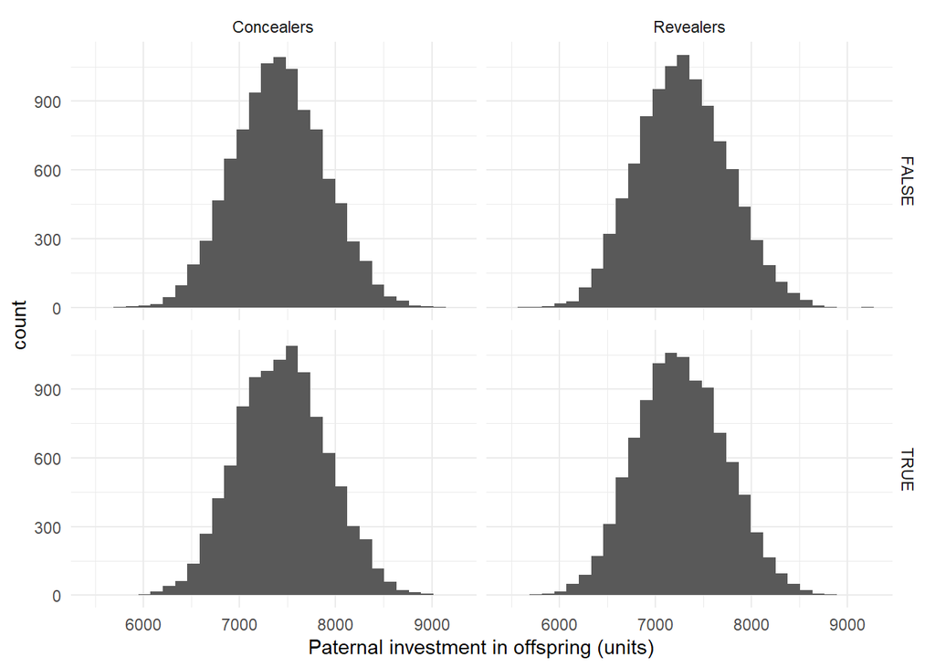

```r
d %>%
  filter(Experiment == 2) %>%

  ggplot(aes(x = PI)) +
  geom_histogram(bins=30) +
  facet_grid(Decrement ~ Strategy) +
  xlab('Paternal investment in offspring (units)') +
  theme_minimal()
```

These also look normally-distributed. Run paired t-tests to look for differences between strategies.

```r
PI.dFalse.Revealers  <- d %>% filter(Experiment==2, Decrement=='FALSE', Strategy=='Revealers') %>% pull(PI)
PI.dFalse.Concealers <- d %>% filter(Experiment==2, Decrement=='FALSE', Strategy=='Concealers') %>% pull(PI)
PI.dTrue.Revealers   <- d %>% filter(Experiment==2, Decrement=='TRUE', Strategy=='Revealers') %>% pull(PI)
PI.dTrue.Concealers  <- d %>% filter(Experiment==2, Decrement=='TRUE', Strategy=='Concealers') %>% pull(PI)

t.test(PI.dFalse.Revealers, PI.dFalse.Concealers, paired = TRUE)
```

```
##
##  Paired t-test
##
## data:  PI.dFalse.Revealers and PI.dFalse.Concealers
## t = -18.441, df = 9999, p-value < 2.2e-16
## alternative hypothesis: true difference in means is not equal to 0
## 95 percent confidence interval:
##  -138.8833 -112.1942
## sample estimates:
## mean of the differences
##               -125.5388
```

```r
cohen.d(PI.dFalse.Revealers, PI.dFalse.Concealers, paired = TRUE)
```

```
##
## Cohen's d
##
## d estimate: -0.2699637 (small)
## 95 percent confidence interval:
##      lower      upper
## -0.2991768 -0.2407506
```

When Decrement == FALSE, there is a significant difference between the paternal investment of Revealers (Mean = 7289 units) and Concealers (Mean = 7414 units), with an effect size of -0.27.

```r
t.test(PI.dTrue.Revealers, PI.dTrue.Concealers, paired = TRUE)
```

```
##
##  Paired t-test
##
## data:  PI.dTrue.Revealers and PI.dTrue.Concealers
## t = -26.186, df = 9999, p-value < 2.2e-16
## alternative hypothesis: true difference in means is not equal to 0
## 95 percent confidence interval:
##  -191.4846 -164.8128
## sample estimates:
## mean of the differences
##               -178.1487
```

```r
cohen.d(PI.dTrue.Revealers, PI.dTrue.Concealers, paired = TRUE)
```

```
##
## Cohen's d
##
## d estimate: -0.3853325 (small)
## 95 percent confidence interval:
##      lower      upper
## -0.4152276 -0.3554375
```

When Decrement == TRUE, there is a significant difference between the paternal investment of Revealers (Mean = 7269 units) and Concealers (Mean = 7447 units), with an effect size of -0.39.

# 3. Experiment 3 (Aggression Towards Ovulating Females)

## 3.1. Reproductive Success

Finally, we turn to Experiment 3. For reproductive success, visualise outcome and check assumptions of normality.

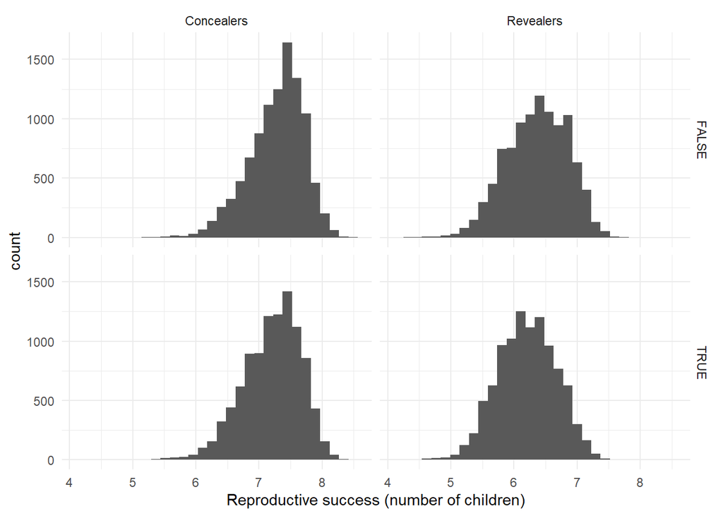

```r
d %>%
  filter(Experiment == 3) %>%

  ggplot(aes(x = RS)) +
  geom_histogram(bins=30) +
  facet_grid(Decrement ~ Strategy) +
  xlab('Reproductive success (number of children)') +
  theme_minimal()
```

As before, these appear normally-distributed (though there is some slight skewness). Next, run paired t-tests.

```r
RS.dFalse.Revealers  <- d %>% filter(Experiment==3, Decrement=='FALSE', Strategy=='Revealers') %>% pull(RS)
RS.dFalse.Concealers <- d %>% filter(Experiment==3, Decrement=='FALSE', Strategy=='Concealers') %>% pull(RS)
RS.dTrue.Revealers   <- d %>% filter(Experiment==3, Decrement=='TRUE', Strategy=='Revealers') %>% pull(RS)
RS.dTrue.Concealers  <- d %>% filter(Experiment==3, Decrement=='TRUE', Strategy=='Concealers') %>% pull(RS)

t.test(RS.dFalse.Revealers, RS.dFalse.Concealers, paired = TRUE)
```

```
##
##  Paired t-test
##
## data:  RS.dFalse.Revealers and RS.dFalse.Concealers
## t = -289.64, df = 9999, p-value < 2.2e-16
## alternative hypothesis: true difference in means is not equal to 0
## 95 percent confidence interval:
##  -0.9196137 -0.9072503
## sample estimates:
## mean of the differences
##               -0.913432
```

```r
cohen.d(RS.dFalse.Revealers, RS.dFalse.Concealers, paired = TRUE)
```

```
##
## Cohen's d
##
## d estimate: -1.973532 (large)
## 95 percent confidence interval:
##     lower     upper
## -1.996461 -1.950604
```

When Decrement == FALSE, there is a significant difference between the reproductive success of Revealers (Mean = 6.37 children) and Concealers (Mean = 7.28 children), with an effect size of -1.97.

```r
t.test(RS.dTrue.Revealers, RS.dTrue.Concealers, paired = TRUE)
```

```
##
##  Paired t-test
##
## data:  RS.dTrue.Revealers and RS.dTrue.Concealers
## t = -329.99, df = 9999, p-value < 2.2e-16
## alternative hypothesis: true difference in means is not equal to 0
## 95 percent confidence interval:
##  -1.0048155 -0.9929485
## sample estimates:
## mean of the differences
##               -0.998882
```

```r
cohen.d(RS.dTrue.Revealers, RS.dTrue.Concealers, paired = TRUE)
```

```
##
## Cohen's d
##
## d estimate: -2.187992 (large)
## 95 percent confidence interval:
##     lower     upper
## -2.211934 -2.164051
```

When Decrement == TRUE, there is again a significant difference between the reproductive success of Revealers (Mean = 6.21 children) and Concealers (Mean = 7.21 children), with an effect size of -2.19.

## 3.2. Paternal Investment

Now we check the PI outcome, in Experiment 3.

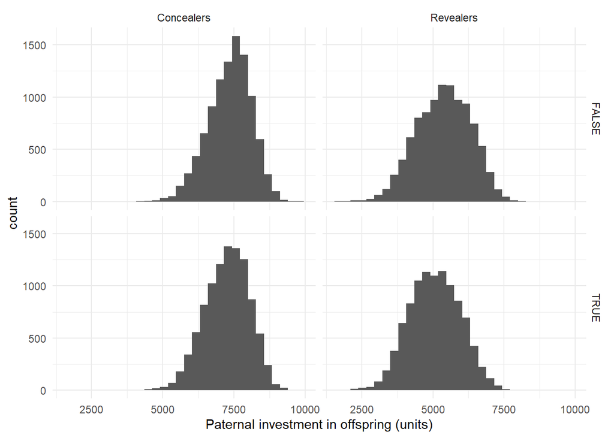

```r
d %>%
  filter(Experiment == 3) %>%

  ggplot(aes(x = PI)) +
  geom_histogram(bins=30) +
  facet_grid(Decrement ~ Strategy) +
  xlab('Paternal investment in offspring (units)') +
  theme_minimal()
```

These also look normally-distributed, with some slight skewness. Run paired t-tests to look for differences between strategies.

```r
PI.dFalse.Revealers  <- d %>% filter(Experiment==3, Decrement=='FALSE', Strategy=='Revealers') %>% pull(PI)
PI.dFalse.Concealers <- d %>% filter(Experiment==3, Decrement=='FALSE', Strategy=='Concealers') %>% pull(PI)
PI.dTrue.Revealers   <- d %>% filter(Experiment==3, Decrement=='TRUE', Strategy=='Revealers') %>% pull(PI)
PI.dTrue.Concealers  <- d %>% filter(Experiment==3, Decrement=='TRUE', Strategy=='Concealers') %>% pull(PI)

t.test(PI.dFalse.Revealers, PI.dFalse.Concealers, paired = TRUE)
```

```
##
##  Paired t-test
##
## data:  PI.dFalse.Revealers and PI.dFalse.Concealers
## t = -285.03, df = 9999, p-value < 2.2e-16
## alternative hypothesis: true difference in means is not equal to 0
## 95 percent confidence interval:
##  -1989.588 -1962.409
## sample estimates:
## mean of the differences
##               -1975.999
```

```r
cohen.d(PI.dFalse.Revealers, PI.dFalse.Concealers, paired = TRUE)
```

```
##
## Cohen's d
##
## d estimate: -2.261205 (large)
## 95 percent confidence interval:
##     lower     upper
## -2.290530 -2.231879
```

When Decrement == FALSE, there is a significant difference between the paternal investment of Revealers (Mean = 5373 units) and Concealers (Mean = 7349 units), with an effect size of -2.26.

```r
t.test(PI.dTrue.Revealers, PI.dTrue.Concealers, paired = TRUE)
```

```
##
##  Paired t-test
##
## data:  PI.dTrue.Revealers and PI.dTrue.Concealers
## t = -336.28, df = 9999, p-value < 2.2e-16
## alternative hypothesis: true difference in means is not equal to 0
## 95 percent confidence interval:
##  -2196.339 -2170.883
## sample estimates:
## mean of the differences
##               -2183.611
```

```r
cohen.d(PI.dTrue.Revealers, PI.dTrue.Concealers, paired = TRUE)
```

```
##
## Cohen's d
##
## d estimate: -2.586817 (large)
## 95 percent confidence interval:
##     lower     upper
## -2.618249 -2.555385
```

When Decrement == TRUE, there is a significant difference between the paternal investment of Revealers (Mean = 5067 units) and Concealers (Mean = 7250 units), with an effect size of -2.59.

# 4. Plotting the results of the main experiments

We create violin plot summarising our outcomes for both Concealers and Revealers, when decrement is both True and False, in all three Experiments. The code is hidden here (see the source .Rmd file), but this is the result for reproductive success:

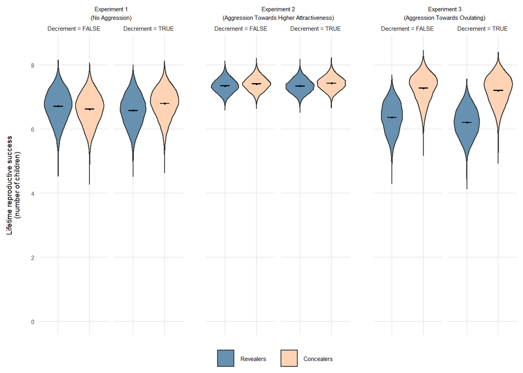

And the plot for paternal investment:

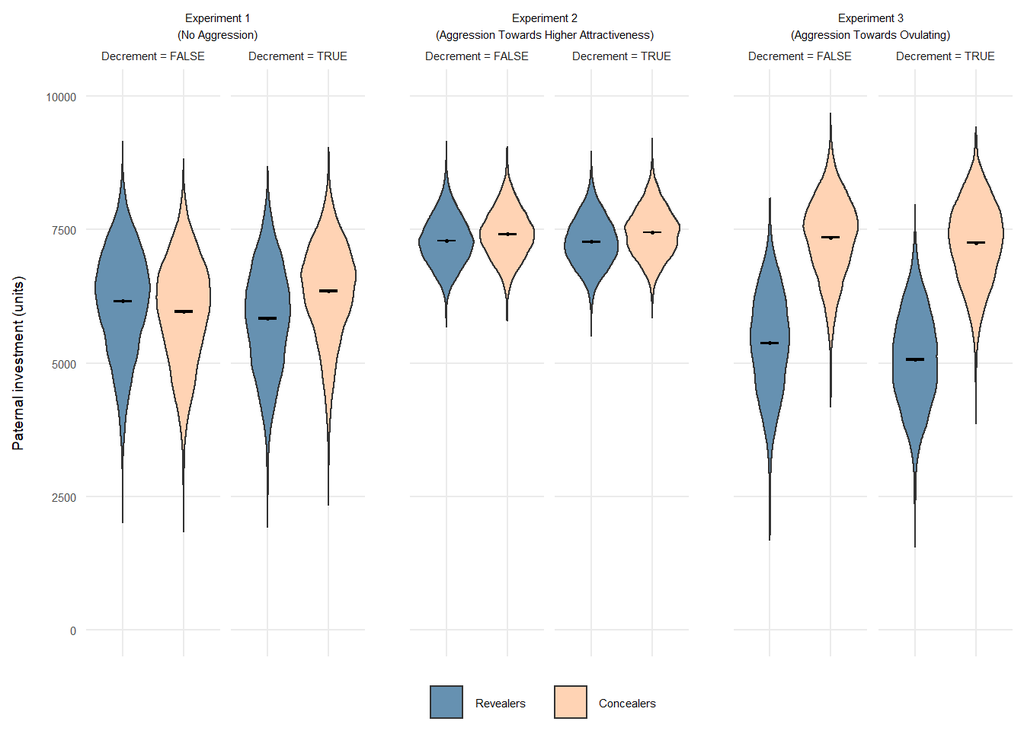